# Trade-offs

August 22, 2018

## Feedback

### Good:

- Enjoyed the videos
- Real life examples like naps and oreos
- Relatable content and examples

### Needs improvement:

- Use the mic
- Go slower, not enough time to take notes
- Provide concrete terms and definitions

## Trade-offs

Since resources are **scarce**, we have to make **trade-offs**. We can’t both *take a nap* and *go to class*, as much as we might want to.

[interactive chart not shown]

[via GIPHY](https://giphy.com/gifs/ifc-funny-season-2-2YehS22GFOIsK1yWEV)

## Trade-offs

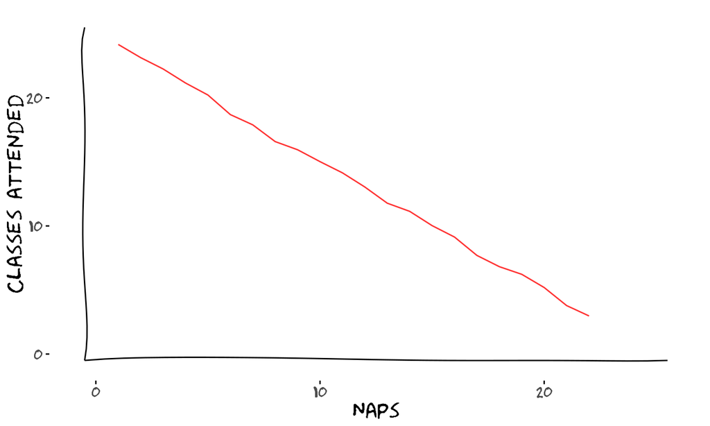

## Production

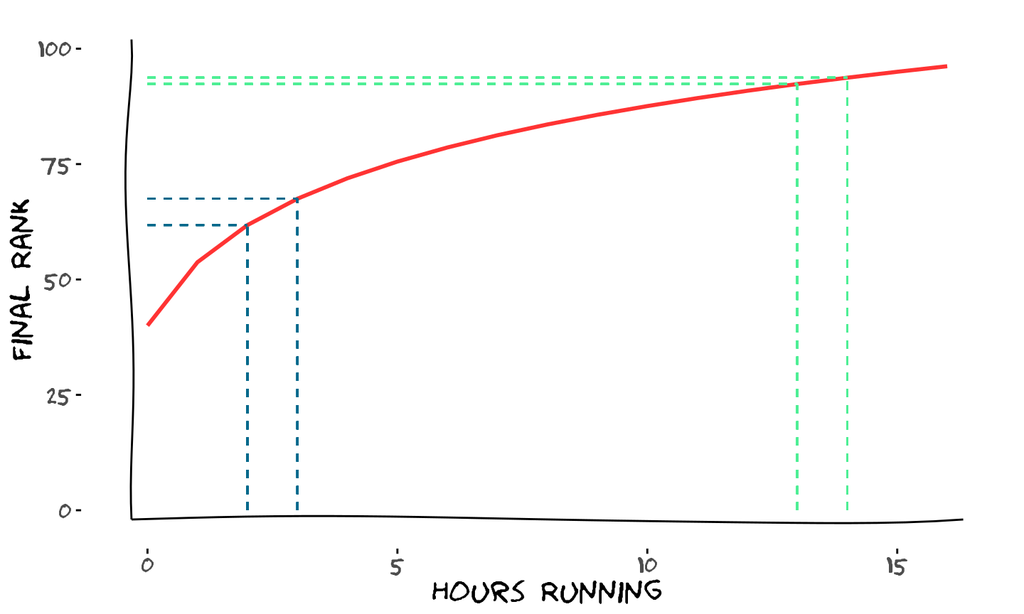

## Production

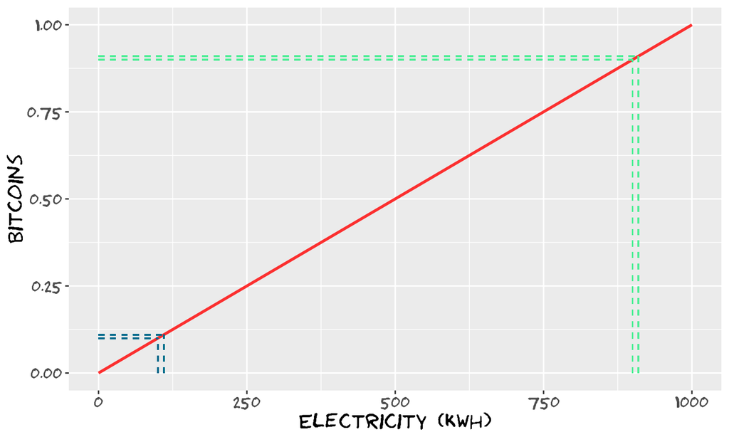

## Marginality

- **Marginality** - *The cost or benefit of an additional item.*

## Marginality in Production

- **Average product** - *The average amount of **production** per unit of input.*
- **Marginal product** - *The additional **production** from increasing a single unit of input.*

## Marginality in Production

[Figure 3.5 from The Economy](https://core-econ.org/the-economy/book/text/03.html#figure-3-5a)

## Marginality of Consumption

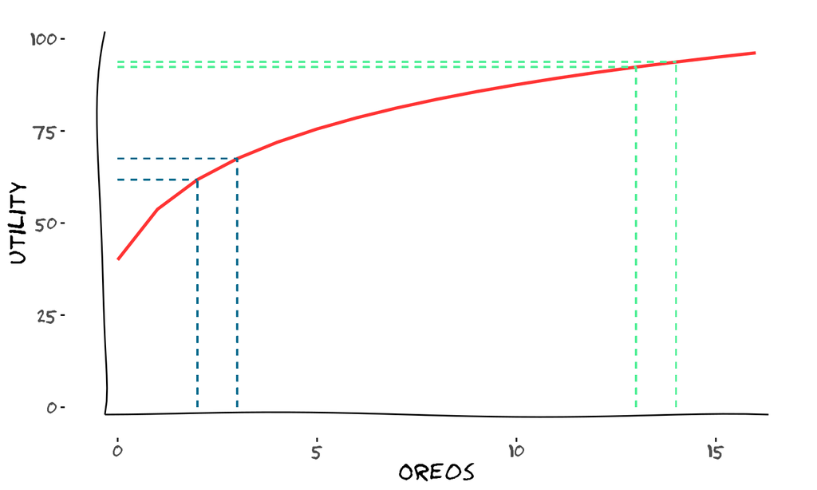

## Marginality in Consumption

- **Average utility** - The average amount of **utility** per unit of consumption.
- **Marginal utility** - The additional **utility** from consuming an additional unit.

## WSU: An example

WSU Tuition: $5,134

Cost of classes:

| Classes | Total Cost | Marginal Cost | Average Cost |
| --- | --- | --- | --- |
| 1 | 1000 | 1000 | 1000 |
| 2 | 1750 | 750 | 875 |
| 3 | 2350 | ??? | 783.3 |
| 4 | ???? | 250 | ??? |
| 5 | 2850 | 250 | 570 |

## Possibility Frontiers

- **Production possibility frontier** - *the line denoting how much of one good can be produced given production of all other goods.*

*What do we want to produce with our resources?*

- **Consumption possiblity frontier** - *the line denoting how much of one good we can afford to consume given consumption of all other goods.*

*How do we want to spend our money?*

## Production possibility frontier

[Figure 3.9 from The Economy](https://core-econ.org/the-economy/book/text/03.html#figure-3-9a)

## Opportunity Cost

- **Opportunity Cost** - *The value of the best alternative we must give up when we make a choice.*

## Increasing Opportunity Cost

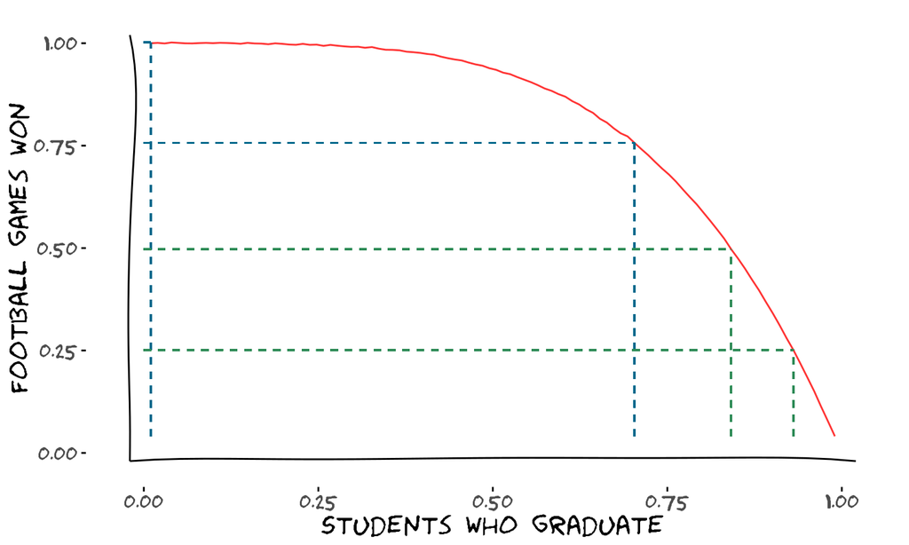

## Economic Growth

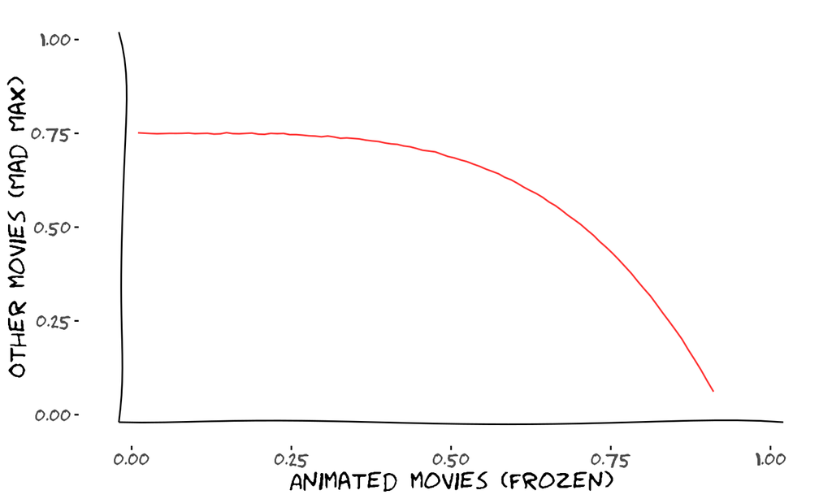

## Economic Growth

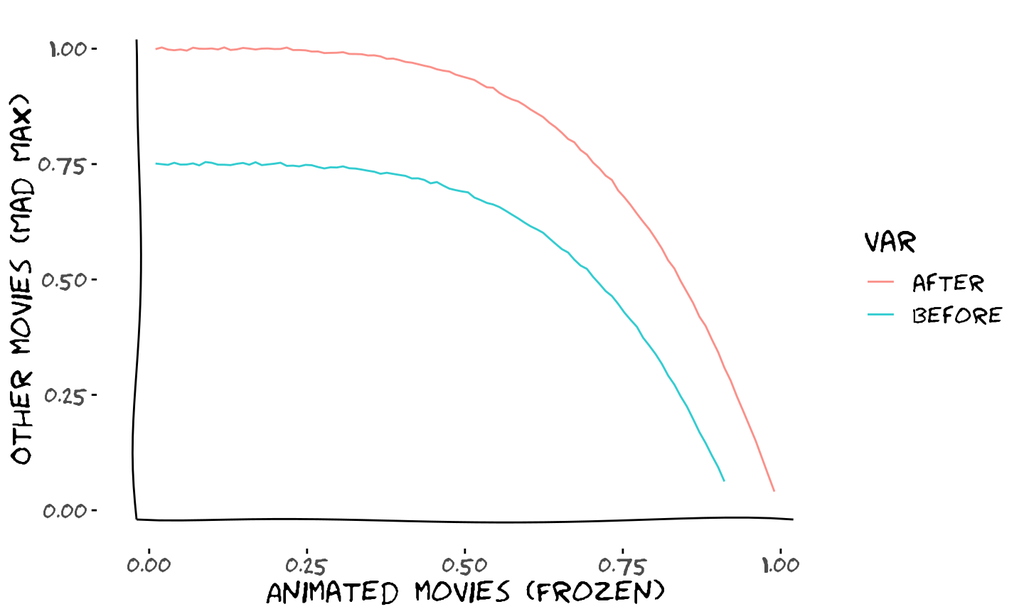

## Economic Growth

If we can produce more, we can provide more basic goods to people who need them, and more luxury goods to people who want them. *We become more well off.*

But how?

- Increase in available resources
- Technological advances

## Increased availability of resources

[video not shown]

## Technological advances

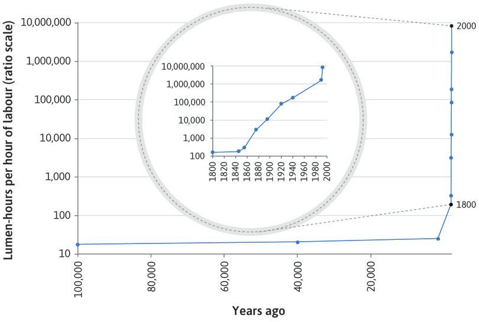

## Wrapping Up

- Complete the [knowledge check](https://goo.gl/forms/L9w8WyzTnRS1QP6H2) for today’s participation point.
- Please provide [feedback](https://goo.gl/forms/8SiOwdi19kN8cINJ3) on today’s lecture.